# Regularization on Mice Protein Expression Data Set

Insofe Labs

# Data Description

[output not shown]

```r
# Attribute Information:
#
# 1 Mouse ID
# 2-78 Values of expression levels of 77 proteins; the names of proteins
# 79 Genotype: control (c) or trisomy (t)
# 80 Treatment type: memantine (m) or saline (s)
# 81 Behavior: context-shock (CS) or shock-context (SC)
# # 82 Class: c-CS-s, c-CS-m, c-SC-s, c-SC-m, t-CS-s, t-CS-m, t-SC-s, t-SC-m
# Classes:
# c-CS-s: control mice, stimulated to learn, injected with saline (9 mice)
# c-CS-m: control mice, stimulated to learn, injected with memantine (10 mice)
# c-SC-s: control mice, not stimulated to learn, injected with saline (9 mice)
# c-SC-m: control mice, not stimulated to learn, injected with memantine (10 mice)
# t-CS-s: trisomy mice, stimulated to learn, injected with saline (7 mice)
# t-CS-m: trisomy mice, stimulated to learn, injected with memantine (9 mice)
# t-SC-s: trisomy mice, not stimulated to learn, injected with saline (9 mice)
# t-SC-m: trisomy mice, not stimulated to learn, injected with memantine (9 mice)
```

# Clean Your Global Environment

- Note that clearing the environment is a good practice while learning but when sharing the code remember to remove it.

```r
rm(list=ls(all=TRUE))
```

# Libraries Required

- Keeping the libraris at one place is a best practice
- Think and get the libraries required for the problem

```r
library(glmnet)
library(caret)
library(MASS)
library(vegan)
library(data.table)
library(doParallel)
library(DMwR)
library(dummies)
```

# Reading the Data Set

- Note that it is not always needed to get the directory set
- Just copy your csv and paste it between the quotes " " and deleted file:///

```r
data<-read.csv("Data_Cortex_Nuclear.csv",header=TRUE,sep=",",na.strings=c(" ",""))
```

## Structure Check

- Observing the structure will reveal what are the data types of attributes
- It can be helpful to understand any data type changes are required

```r
str(data)
```

```
'data.frame':   1080 obs. of  82 variables:
 $ MouseID        : Factor w/ 1080 levels "18899_1","18899_10",..: 46 53 54 55 56 57 58 59 60 47 ...
 $ DYRK1A_N       : num  0.504 0.515 0.509 0.442 0.435 ...
 $ ITSN1_N        : num  0.747 0.689 0.73 0.617 0.617 ...
 $ BDNF_N         : num  0.43 0.412 0.418 0.359 0.359 ...
 $ NR1_N          : num  2.82 2.79 2.69 2.47 2.37 ...
 $ NR2A_N         : num  5.99 5.69 5.62 4.98 4.72 ...
 $ pAKT_N         : num  0.219 0.212 0.209 0.223 0.213 ...
 $ pBRAF_N        : num  0.178 0.173 0.176 0.176 0.174 ...
 $ pCAMKII_N      : num  2.37 2.29 2.28 2.15 2.13 ...
 $ pCREB_N        : num  0.232 0.227 0.23 0.207 0.192 ...
 $ pELK_N         : num  1.75 1.6 1.56 1.6 1.5 ...
 $ pERK_N         : num  0.688 0.695 0.677 0.583 0.551 ...
 $ pJNK_N         : num  0.306 0.299 0.291 0.297 0.287 ...
 $ PKCA_N         : num  0.403 0.386 0.381 0.377 0.364 ...
```

[output cut: 68 more lines]

```r
#data$Treatment = as.numeric(data$Treatment)
#data$Genotype = as.numeric(data$Genotype)
#data$Behavior = as.numeric(data$Behavior)
#data$class = as.numeric(data$class)
#str(data)
```

## Summary Check

- check the summary and remove unnecessary variables
- It is necessary to see basic stats of the variables
- NA values,Classes in the target and other attributes are counted in Summary

```r
summary(data)
```

```
     MouseID        DYRK1A_N         ITSN1_N           BDNF_N           NR1_N
 18899_1 :   1   Min.   :0.1453   Min.   :0.2454   Min.   :0.1152   Min.   :1.331
 18899_10:   1   1st Qu.:0.2881   1st Qu.:0.4734   1st Qu.:0.2874   1st Qu.:2.057
 18899_11:   1   Median :0.3664   Median :0.5658   Median :0.3166   Median :2.297
 18899_12:   1   Mean   :0.4258   Mean   :0.6171   Mean   :0.3191   Mean   :2.297
 18899_13:   1   3rd Qu.:0.4877   3rd Qu.:0.6980   3rd Qu.:0.3482   3rd Qu.:2.528
 18899_14:   1   Max.   :2.5164   Max.   :2.6027   Max.   :0.4972   Max.   :3.758
 (Other) :1074   NA's   :3        NA's   :3        NA's   :3        NA's   :3
     NR2A_N          pAKT_N           pBRAF_N          pCAMKII_N        pCREB_N
 Min.   :1.738   Min.   :0.06324   Min.   :0.06404   Min.   :1.344   Min.   :0.1128
 1st Qu.:3.156   1st Qu.:0.20575   1st Qu.:0.16459   1st Qu.:2.480   1st Qu.:0.1908
 Median :3.761   Median :0.23118   Median :0.18230   Median :3.327   Median :0.2106
 Mean   :3.844   Mean   :0.23317   Mean   :0.18185   Mean   :3.537   Mean   :0.2126
 3rd Qu.:4.440   3rd Qu.:0.25726   3rd Qu.:0.19742   3rd Qu.:4.482   3rd Qu.:0.2346
 Max.   :8.483   Max.   :0.53905   Max.   :0.31707   Max.   :7.464   Max.   :0.3062
 NA's   :3       NA's   :3         NA's   :3         NA's   :3       NA's   :3
     pELK_N          pERK_N           pJNK_N            PKCA_N           pMEK_N
 Min.   :0.429   Min.   :0.1492   Min.   :0.05211   Min.   :0.1914   Min.   :0.05682
 1st Qu.:1.204   1st Qu.:0.3374   1st Qu.:0.28124   1st Qu.:0.2818   1st Qu.:0.24429
 Median :1.356   Median :0.4436   Median :0.32133   Median :0.3130   Median :0.27739
 Mean   :1.429   Mean   :0.5459   Mean   :0.31351   Mean   :0.3179   Mean   :0.27503
 3rd Qu.:1.561   3rd Qu.:0.6633   3rd Qu.:0.34871   3rd Qu.:0.3523   3rd Qu.:0.30345
 Max.   :6.113   Max.   :3.5667   Max.   :0.49343   Max.   :0.4740   Max.   :0.45800
 NA's   :3       NA's   :3        NA's   :3         NA's   :3        NA's   :3
     pNR1_N          pNR2A_N          pNR2B_N          pPKCAB_N          pRSK_N
 Min.   :0.5002   Min.   :0.2813   Min.   :0.3016   Min.   :0.5678   Min.   :0.09594
 1st Qu.:0.7435   1st Qu.:0.5903   1st Qu.:1.3813   1st Qu.:1.1683   1st Qu.:0.40414
 Median :0.8211   Median :0.7196   Median :1.5637   Median :1.3657   Median :0.44060
 Mean   :0.8258   Mean   :0.7269   Mean   :1.5620   Mean   :1.5253   Mean   :0.44285
 3rd Qu.:0.8985   3rd Qu.:0.8486   3rd Qu.:1.7485   3rd Qu.:1.8859   3rd Qu.:0.48210
 Max.   :1.4082   Max.   :1.4128   Max.   :2.7240   Max.   :3.0614   Max.   :0.65096
 NA's   :3        NA's   :3        NA's   :3        NA's   :3        NA's   :3
     AKT_N             BRAF_N          CAMKII_N          CREB_N           ELK_N
 Min.   :0.06442   Min.   :0.1439   Min.   :0.2130   Min.   :0.1136   Min.   :0.4977
 1st Qu.:0.59682   1st Qu.:0.2643   1st Qu.:0.3309   1st Qu.:0.1618   1st Qu.:0.9444
 Median :0.68247   Median :0.3267   Median :0.3603   Median :0.1796   Median :1.0962
 Mean   :0.68224   Mean   :0.3785   Mean   :0.3634   Mean   :0.1805   Mean   :1.1734
 3rd Qu.:0.75969   3rd Qu.:0.4136   3rd Qu.:0.3939   3rd Qu.:0.1957   3rd Qu.:1.3236
 Max.   :1.18217   Max.   :2.1334   Max.   :0.5862   Max.   :0.3196   Max.   :2.8029
 NA's   :3         NA's   :3        NA's   :3        NA's   :3        NA's   :18
```

[output cut: 81 more lines]

```
 Min.   :0.1055   Min.   :0.1018   Min.   :0.5865   Control:570   Memantine:570   C/S:525
 1st Qu.:0.1551   1st Qu.:0.1651   1st Qu.:1.0814   Ts65Dn :510   Saline   :510   S/C:555
 Median :0.1749   Median :0.1940   Median :1.3174
 Mean   :0.1831   Mean   :0.2054   Mean   :1.3378
 3rd Qu.:0.2045   3rd Qu.:0.2352   3rd Qu.:1.5858
 Max.   :0.3607   Max.   :0.4139   Max.   :2.1298
 NA's   :210      NA's   :270
     class
 c-CS-m :150
 c-SC-m :150
 c-SC-s :140
 c-CS-s :135
 t-SC-m :135
 t-SC-s :135
 (Other):235
```

```r
#data$MouseID = NULL
```

## Check Missing Values

- Missing values impact the learning

```r
sum(is.na(data))
```

```
[1] 1396
```

*What is the percentage of the NA values ?

```r
#na.percentage
perMiss = function(x){ (sum(is.na(x))/length(x))*100}
apply(data,2,perMiss)
```

```
        MouseID        DYRK1A_N         ITSN1_N          BDNF_N           NR1_N          NR2A_N
      0.0000000       0.2777778       0.2777778       0.2777778       0.2777778       0.2777778
         pAKT_N         pBRAF_N       pCAMKII_N         pCREB_N          pELK_N          pERK_N
      0.2777778       0.2777778       0.2777778       0.2777778       0.2777778       0.2777778
         pJNK_N          PKCA_N          pMEK_N          pNR1_N         pNR2A_N         pNR2B_N
      0.2777778       0.2777778       0.2777778       0.2777778       0.2777778       0.2777778
       pPKCAB_N          pRSK_N           AKT_N          BRAF_N        CAMKII_N          CREB_N
      0.2777778       0.2777778       0.2777778       0.2777778       0.2777778       0.2777778
          ELK_N           ERK_N         GSK3B_N           JNK_N           MEK_N          TRKA_N
      1.6666667       0.2777778       0.2777778       0.2777778       0.6481481       0.2777778
          RSK_N           APP_N      Bcatenin_N          SOD1_N          MTOR_N           P38_N
      0.2777778       0.2777778       1.6666667       0.2777778       0.2777778       0.2777778
        pMTOR_N         DSCR1_N         AMPKA_N          NR2B_N         pNUMB_N        RAPTOR_N
      0.2777778       0.2777778       0.2777778       0.2777778       0.2777778       0.2777778
        TIAM1_N        pP70S6_N          NUMB_N         P70S6_N        pGSK3B_N         pPKCG_N
      0.2777778       0.2777778       0.0000000       0.0000000       0.0000000       0.0000000
         CDK5_N            S6_N        ADARB1_N    AcetylH3K9_N          RRP1_N           BAX_N
      0.0000000       0.0000000       0.0000000       0.0000000       0.0000000       0.0000000
          ARC_N         ERBB4_N          nNOS_N           Tau_N          GFAP_N         GluR3_N
      0.0000000       0.0000000       0.0000000       0.0000000       0.0000000       0.0000000
        GluR4_N          IL1B_N         P3525_N        pCASP9_N         PSD95_N          SNCA_N
      0.0000000       0.0000000       0.0000000       0.0000000       0.0000000       0.0000000
    Ubiquitin_N pGSK3B_Tyr216_N           SHH_N           BAD_N          BCL2_N           pS6_N
      0.0000000       0.0000000       0.0000000      19.7222222      26.3888889       0.0000000
        pCFOS_N           SYP_N       H3AcK18_N          EGR1_N        H3MeK4_N          CaNA_N
      6.9444444       0.0000000      16.6666667      19.4444444      25.0000000       0.0000000
       Genotype       Treatment        Behavior           class
      0.0000000       0.0000000       0.0000000       0.0000000
```

*Impute the NA values using a suitable technique

```r
library(DMwR)
impData = knnImputation(data = data,k = 10,scale = T,meth = 'weighAvg')
#pmm = predictive mean matching
sum(is.na(impData))
```

```
[1] 0
```

*Check for the summary

```r
summary(impData)
```

```
     MouseID        DYRK1A_N         ITSN1_N           BDNF_N           NR1_N
 18899_1 :   1   Min.   :0.1453   Min.   :0.2454   Min.   :0.1152   Min.   :1.331
 18899_10:   1   1st Qu.:0.2882   1st Qu.:0.4737   1st Qu.:0.2877   1st Qu.:2.059
 18899_11:   1   Median :0.3665   Median :0.5664   Median :0.3167   Median :2.296
 18899_12:   1   Mean   :0.4257   Mean   :0.6171   Mean   :0.3191   Mean   :2.297
 18899_13:   1   3rd Qu.:0.4876   3rd Qu.:0.6975   3rd Qu.:0.3480   3rd Qu.:2.528
 18899_14:   1   Max.   :2.5164   Max.   :2.6027   Max.   :0.4972   Max.   :3.758
 (Other) :1074
     NR2A_N          pAKT_N           pBRAF_N          pCAMKII_N        pCREB_N
 Min.   :1.738   Min.   :0.06324   Min.   :0.06404   Min.   :1.344   Min.   :0.1128
 1st Qu.:3.160   1st Qu.:0.20582   1st Qu.:0.16462   1st Qu.:2.480   1st Qu.:0.1908
 Median :3.739   Median :0.23125   Median :0.18247   Median :3.330   Median :0.2107
 Mean   :3.843   Mean   :0.23321   Mean   :0.18188   Mean   :3.538   Mean   :0.2126
 3rd Qu.:4.425   3rd Qu.:0.25722   3rd Qu.:0.19744   3rd Qu.:4.481   3rd Qu.:0.2346
 Max.   :8.483   Max.   :0.53905   Max.   :0.31707   Max.   :7.464   Max.   :0.3062

     pELK_N          pERK_N           pJNK_N            PKCA_N           pMEK_N
 Min.   :0.429   Min.   :0.1492   Min.   :0.05211   Min.   :0.1914   Min.   :0.05682
 1st Qu.:1.206   1st Qu.:0.3375   1st Qu.:0.28153   1st Qu.:0.2818   1st Qu.:0.24429
 Median :1.355   Median :0.4442   Median :0.32135   Median :0.3130   Median :0.27746
 Mean   :1.428   Mean   :0.5457   Mean   :0.31358   Mean   :0.3180   Mean   :0.27510
 3rd Qu.:1.561   3rd Qu.:0.6632   3rd Qu.:0.34869   3rd Qu.:0.3523   3rd Qu.:0.30335
 Max.   :6.113   Max.   :3.5667   Max.   :0.49343   Max.   :0.4740   Max.   :0.45800

     pNR1_N          pNR2A_N          pNR2B_N          pPKCAB_N          pRSK_N
 Min.   :0.5002   Min.   :0.2813   Min.   :0.3016   Min.   :0.5678   Min.   :0.09594
 1st Qu.:0.7436   1st Qu.:0.5913   1st Qu.:1.3807   1st Qu.:1.1686   1st Qu.:0.40415
 Median :0.8209   Median :0.7196   Median :1.5632   Median :1.3688   Median :0.44064
 Mean   :0.8257   Mean   :0.7269   Mean   :1.5614   Mean   :1.5254   Mean   :0.44309
 3rd Qu.:0.8983   3rd Qu.:0.8473   3rd Qu.:1.7485   3rd Qu.:1.8812   3rd Qu.:0.48244
 Max.   :1.4082   Max.   :1.4128   Max.   :2.7240   Max.   :3.0614   Max.   :0.65096

     AKT_N             BRAF_N          CAMKII_N          CREB_N           ELK_N
 Min.   :0.06442   Min.   :0.1439   Min.   :0.2130   Min.   :0.1136   Min.   :0.4977
 1st Qu.:0.59732   1st Qu.:0.2644   1st Qu.:0.3309   1st Qu.:0.1619   1st Qu.:0.9428
 Median :0.68196   Median :0.3267   Median :0.3603   Median :0.1796   Median :1.0928
 Mean   :0.68221   Mean   :0.3784   Mean   :0.3634   Mean   :0.1806   Mean   :1.1698
 3rd Qu.:0.75891   3rd Qu.:0.4127   3rd Qu.:0.3938   3rd Qu.:0.1958   3rd Qu.:1.3182
 Max.   :1.18217   Max.   :2.1334   Max.   :0.5862   Max.   :0.3196   Max.   :2.8029

```

[output cut: 81 more lines]

```
 Min.   :0.1055   Min.   :0.1018   Min.   :0.5865   Control:570   Memantine:570   C/S:525
 1st Qu.:0.1557   1st Qu.:0.1657   1st Qu.:1.0814   Ts65Dn :510   Saline   :510   S/C:555
 Median :0.1758   Median :0.1952   Median :1.3174
 Mean   :0.1843   Mean   :0.2043   Mean   :1.3378
 3rd Qu.:0.2067   3rd Qu.:0.2349   3rd Qu.:1.5858
 Max.   :0.3607   Max.   :0.4139   Max.   :2.1298

     class
 c-CS-m :150
 c-SC-m :150
 c-SC-s :140
 c-CS-s :135
 t-SC-m :135
 t-SC-s :135
 (Other):235
```

# Target levels Distribution

```r
 table(impData$class)
```

```
c-CS-m c-CS-s c-SC-m c-SC-s t-CS-m t-CS-s t-SC-m t-SC-s
   150    135    150    140    130    105    135    135
```

# Splitting the data

- Split the data into train data set and test data set
- Split ratio can be 80/20 or 70/30
- Splitting in case of classification be careful to see that the levels of target distribution is in same proportion in both train and test
- This can be achieved with the Caret Package “createDataPartition”

```r
set.seed(123)
rows=createDataPartition(impData$class,p = 0.7,list = FALSE)
train = impData[rows,]
test = impData[-rows,]
```

# Testing the Class Distribution Later

```r
table(train$class)
```

```
c-CS-m c-CS-s c-SC-m c-SC-s t-CS-m t-CS-s t-SC-m t-SC-s
   105     95    105     98     91     74     95     95
```

```r
levels(train$class)
```

```
[1] "c-CS-m" "c-CS-s" "c-SC-m" "c-SC-s" "t-CS-m" "t-CS-s" "t-SC-m" "t-SC-s"
```

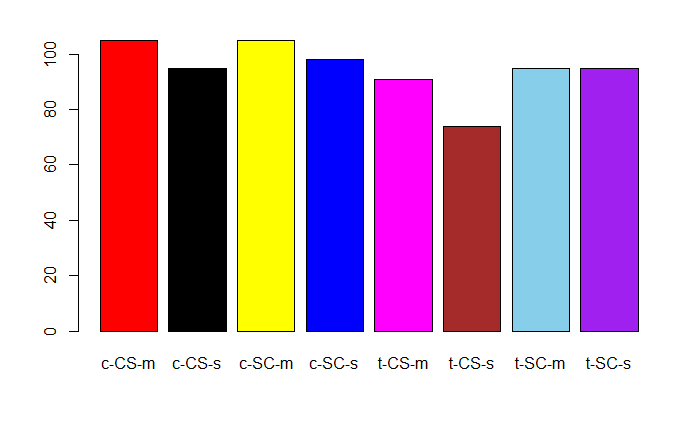

```r
plot(train$class,col=c("red","black","yellow","blue","magenta","brown","skyblue","purple"))
```

```r
table(test$class)
```

```
c-CS-m c-CS-s c-SC-m c-SC-s t-CS-m t-CS-s t-SC-m t-SC-s
    45     40     45     42     39     31     40     40
```

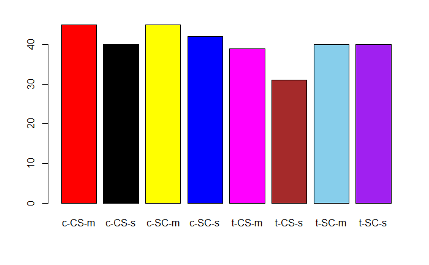

```r
plot(test$class,col=c("red","black","yellow","blue","magenta","brown","skyblue","purple"))
```

# Standardization

*Standardization is needed beacause the higher values of the attibute should not dominate the model.

```r
#PreProcessing Required to standardize the attributes
preProc<-preProcess(train[,setdiff(names(train),"class")])
train<-predict(preProc,train)
test<-predict(preProc,test)
#train.predictors = train[,-81]
#scaled_train = scale(train.predictors)
#test.predictors = test[,-81]
#scaled_test = scale(test.predictors)
```

# Parallel

- Use the registerDoParallel() to speed up your process while cross validating
- Those who use linux doMC also helps the same way by creating multiple cores

```r
registerDoParallel(8)
```

# Dummify the variables

```r
train$MouseID =NULL
x=model.matrix(train$class~.,train)
head(x)
```

```
  (Intercept)    DYRK1A_N     ITSN1_N    BDNF_N       NR1_N    NR2A_N     pAKT_N     pBRAF_N
1           1  0.34110570  0.56810581 2.3290810  1.55247109 2.3476469 -0.3488462 -0.15663812
3           1  0.36394847  0.49823995 2.0839782  1.17696959 1.9508390 -0.5881599 -0.22353042
5           1  0.05778315  0.03312407 0.8548709  0.24229425 0.9769870 -0.4883545 -0.29956663
6           1  0.10960386  0.07742709 1.0322123  0.30090216 1.0728832 -0.3549942 -0.20498076
7           1  0.02929751 -0.14718039 0.5224659  0.15051480 0.7122833 -0.1942573  0.07700601
8           1 -0.01651864 -0.18700681 0.2125114 -0.06493424 0.4919431 -0.4462344 -0.08032735
   pCAMKII_N    pCREB_N      pELK_N      pERK_N     pJNK_N    PKCA_N      pMEK_N      pNR1_N
1 -0.8987772  0.6375213 0.706364685  0.45692575 -0.1342781 1.6454743  0.45786504  1.72984691
3 -0.9684185  0.5759360 0.301229350  0.42511353 -0.4227389 1.2306868  0.13143342  1.57116703
5 -1.0834420 -0.6105898 0.179260265  0.04428915 -0.5051366 0.8961107  0.05107344  0.37647612
6 -1.0778429 -0.5162129 0.047152364  0.09062942 -0.4504697 0.9035842 -0.18762823  0.32660197
7 -1.1771107 -0.4974819 0.409596719 -0.07943207 -0.2627463 1.0423293  0.04445088  0.19879442
8 -1.1805218 -0.6839352 0.009126868 -0.10602143 -0.5804754 0.8076668 -0.41045487 -0.02200017
     pNR2A_N     pNR2B_N  pPKCAB_N      pRSK_N       AKT_N      BRAF_N    CAMKII_N      CREB_N
```

[output cut: 55 more lines]

# Lasso Model

- Lasso always fits a linear model
- It involves penalizing the absolute size of the regression coefficients.
- For regularization glmnet package is used.
- This package is used for both regression and classification
- Linear,Poisson regressions ,binomial and multinomial classifications are possible
- Check the help with ?glmnet and use the arguments needed

```r
#x=model.matrix()
#model=glmnet()
fit.lasso <- glmnet(x, train$class, family="multinomial", alpha=1)
#Effect of various Alpha on Model
for (i in 0:100) {
    assign(paste("fit", i, sep=""), cv.glmnet(x,train$class, type.measure="class",
                                              alpha=i/100,family="multinomial",nfolds=10,parallel=TRUE))
}
```

## Plots for Different Lambda

- Plot the model for different lambda values as modelled above
- The plot justifies that for different values of lambda there are different attributes which are moving towards zero.
- But the question is What is the optimum value for lambda??

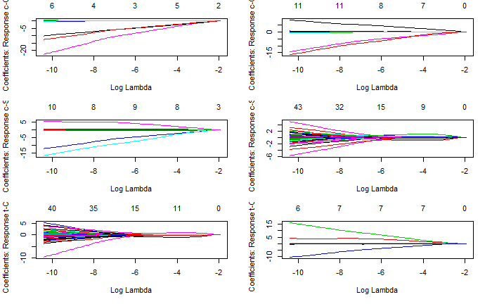

```r
#plot(model)
par(mfrow=c(3,2))
plot(fit.lasso, xvar="lambda")
```

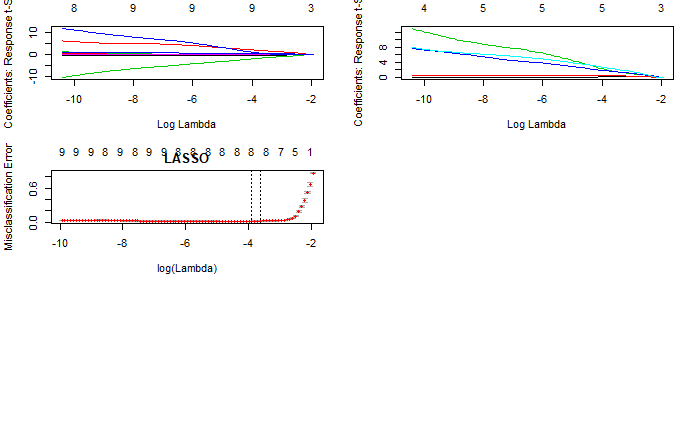

```r
plot(fit100, main="LASSO")
```

## Cross Validation for Lasso

```r
#cv.model<-cv.glmnet()
cv.model = cv.glmnet(x,train$class,type.measure = "class",alpha=1,
                          family="multinomial",nfolds=10,parallel=TRUE)
```

## Predicting the Min Lambda

- plot the Cross validated model to choose the minimum lambda

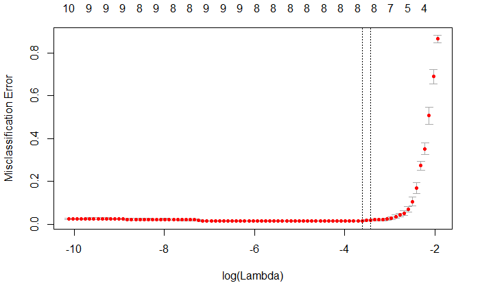

```r
plot(cv.model)
```

```r
cv.model$lambda.min
```

```
[1] 0.02693377
```

```r
 #0.01856441
```

Perform the model with the lambda min choosen

```r
newmodel=glmnet(x,train$class,family = "multinomial",type.multinomial = "grouped",lambda = cv.model$lambda.min)
```

## Getting the Coefficnets for Lasso

- code to get the coefficients that are not zero from the Lasso model

```r
coef=coef(newmodel,s = cv.model$lambda.min)
 ind <- which(coef(newmodel,s = cv.model$lambda.min)[[1]] != 0)
 df_lass0 <- data.frame(
        feature=rownames(coef(newmodel, s=cv.model$lambda.min)[[1]])[ind],
        coeficient=(coef(newmodel, s=cv.model$lambda.min)[[1]])[ind])
 df_lass0
```

| feature | coeficient |
| --- | --- |
| (Intercept) | 4.887714e+00 |
| AKT_N | 1.366421e-02 |
| pNUMB_N | 8.245025e-02 |
| pP70S6_N | -3.938710e-03 |
| pPKCG_N | -1.255686e-02 |
| ARC_N | 1.158254e-05 |
| pS6_N | 8.454853e-03 |
| GenotypeTs65Dn | -4.183361e+00 |
| TreatmentSaline | -3.262788e+00 |
| BehaviorS/C | -3.236397e+00 |

# Prediction on Lasso

- Convert the test data set into required format as done prior to the model

```r
#remove unwanted variable
test$MouseID = NULL
#Standardise the attributes
preProc<-preProcess(train[,setdiff(names(train),"class")])
test = predict(preProc,test)
#converting test data into required format
x.test=model.matrix(test$class~.,test)
y.test = test$class
head(y.test)
```

```
[1] c-CS-m c-CS-m c-CS-m c-CS-m c-CS-m c-CS-m
Levels: c-CS-m c-CS-s c-SC-m c-SC-s t-CS-m t-CS-s t-SC-m t-SC-s
```

```r
#pred = predict(cv.model,x.test,s = cv.model$lambda.min)
#str(pred)
pd = predict(object = cv.model,newx = x.test,s = cv.model$lambda.min,type = "class")
str(pd)
```

```
 chr [1:322, 1] "c-CS-m" "c-CS-m" "c-CS-m" "c-CS-m" "c-CS-m" "c-CS-m" "c-CS-m" "c-CS-m" ...
 - attr(*, "dimnames")=List of 2
  ..$ : NULL
  ..$ : chr "1"
```

```r
#regr.eval(y.test,pred.lasso.csv)
```

Form the table of the confusion matrix

```r
#prd = pred[,1,]
Confusionmatrix = table(test$class,pd,dnn=c("actual","predicted"))
Confusionmatrix
```

```
        predicted
actual   c-CS-m c-CS-s c-SC-m c-SC-s t-CS-m t-CS-s t-SC-m t-SC-s
  c-CS-m     45      0      0      0      0      0      0      0
  c-CS-s      0     40      0      0      0      0      0      0
  c-SC-m      0      0     45      0      0      0      0      0
  c-SC-s      0      0      0     36      6      0      0      0
  t-CS-m      0      0      0      1     38      0      0      0
  t-CS-s      0      0      0      0      0     31      0      0
  t-SC-m      0      0      0      0      0      0     40      0
  t-SC-s      0      0      0      0      0      0      0     40
```

## Confusion Matrix

Use the confusion matrix and study the various metrics

```r
#confusionMatrix(pred,test$class)
confusionMatrix(data = pd,reference = test$class)
```

```
Confusion Matrix and Statistics

          Reference
Prediction c-CS-m c-CS-s c-SC-m c-SC-s t-CS-m t-CS-s t-SC-m t-SC-s
    c-CS-m     45      0      0      0      0      0      0      0
    c-CS-s      0     40      0      0      0      0      0      0
    c-SC-m      0      0     45      0      0      0      0      0
    c-SC-s      0      0      0     36      1      0      0      0
    t-CS-m      0      0      0      6     38      0      0      0
    t-CS-s      0      0      0      0      0     31      0      0
    t-SC-m      0      0      0      0      0      0     40      0
    t-SC-s      0      0      0      0      0      0      0     40

Overall Statistics

               Accuracy : 0.9783
                 95% CI : (0.9557, 0.9912)
    No Information Rate : 0.1398
    P-Value [Acc > NIR] : < 2.2e-16

                  Kappa : 0.9751
 Mcnemar's Test P-Value : NA

Statistics by Class:

                     Class: c-CS-m Class: c-CS-s Class: c-SC-m Class: c-SC-s Class: t-CS-m
Sensitivity                 1.0000        1.0000        1.0000        0.8571        0.9744
Specificity                 1.0000        1.0000        1.0000        0.9964        0.9788
Pos Pred Value              1.0000        1.0000        1.0000        0.9730        0.8636
Neg Pred Value              1.0000        1.0000        1.0000        0.9789        0.9964
Prevalence                  0.1398        0.1242        0.1398        0.1304        0.1211
Detection Rate              0.1398        0.1242        0.1398        0.1118        0.1180
Detection Prevalence        0.1398        0.1242        0.1398        0.1149        0.1366
Balanced Accuracy           1.0000        1.0000        1.0000        0.9268        0.9766
                     Class: t-CS-s Class: t-SC-m Class: t-SC-s
Sensitivity                1.00000        1.0000        1.0000
Specificity                1.00000        1.0000        1.0000
Pos Pred Value             1.00000        1.0000        1.0000
Neg Pred Value             1.00000        1.0000        1.0000
Prevalence                 0.09627        0.1242        0.1242
Detection Rate             0.09627        0.1242        0.1242
Detection Prevalence       0.09627        0.1242        0.1242
Balanced Accuracy          1.00000        1.0000        1.0000
```

# Ridge Regression

- Ridge Regression fits a linear equation but with all the features involved
- The features that are not removed by lasso will hava a very least coeffients
- alpha =0 gives the ridge regression
- Ridge can be possible in MASS package using lm.ridge

```r
ridge <- glmnet(x, train$class, family="multinomial", alpha=0)
```

## Cross Validated Model

```r
ridge.cv <- cv.glmnet(x,train$class, type.measure="class", alpha=0,
                          family="multinomial",nfolds=10,parallel=TRUE)
```

## Run the model taking the lambda min

```r
newmodel_ridge = glmnet(x,train$class,family = "multinomial",type.multinomial = "grouped",lambda = ridge.cv$lambda.min)
```

```r
coef_ridge=coef(newmodel_ridge,s = ridge.cv$lambda.min)
ind <- which(coef(newmodel_ridge,s = ridge.cv$lambda.min)[[1]] != 0)
df_ridge <- data.frame(
        feature=rownames(coef(newmodel_ridge, s=ridge.cv$lambda.min)[[1]])[ind],
        coeficient=(coef(newmodel_ridge, s=ridge.cv$lambda.min)[[1]])[ind])
df_ridge
```

| feature | coeficient |
| --- | --- |
| (Intercept) | 5.888489e+00 |
| AKT_N | 2.009399e-02 |
| pNUMB_N | 9.755936e-02 |
| pP70S6_N | -1.026780e-02 |
| pPKCG_N | -1.249701e-02 |
| ARC_N | 1.286258e-06 |
| Ubiquitin_N | -2.388690e-04 |
| pS6_N | 6.227299e-03 |
| GenotypeTs65Dn | -5.409745e+00 |
| TreatmentSaline | -3.870546e+00 |

[output cut: 1 more lines]

# Prediction on Ridge Regularization

Predict the class for the test set

```r
pred_ridge = predict(ridge.cv,x.test,s = ridge.cv$lambda.min,type = "class")
str(pred_ridge)
```

```
 chr [1:322, 1] "c-CS-m" "c-CS-m" "c-CS-m" "c-CS-m" "c-CS-m" "c-CS-m" "c-CS-m" "c-CS-m" ...
 - attr(*, "dimnames")=List of 2
  ..$ : NULL
  ..$ : chr "1"
```

# Elastic Net Regularization

- It is a generalized version of the three regularizations
- It is like alpha x Lasso +(1-alpha) x Ridge
- The value of alpha =0.5 will equalizes the effect.
- alpha can vary between 0 and 1

```r
elastic <- glmnet(x, train$class, family="multinomial", alpha=0.5)
```

## Cross Validated Model

Cross validated model for lambda min

```r
elastic.cv <- cv.glmnet(x,train$class, type.measure="class", alpha=0.5,
                          family="multinomial",nfolds=10,parallel=TRUE)
```

Re Run the model with lambda min

```r
newmodel_elastic = glmnet(x,train$class,family = "multinomial",type.multinomial = "grouped",lambda = elastic.cv$lambda.min)
```

## Getting the Elastic Net attributes

Get the coefficients for elastic net regression

```r
coef_elastic=coef(newmodel_elastic,s = elastic.cv$lambda.min)
ind <- which(coef(newmodel_elastic,s = elastic.cv$lambda.min)[[1]] != 0)
df_elastic <- data.frame(
        feature=rownames(coef(newmodel_elastic, s=elastic.cv$lambda.min)[[1]])[ind],
        coeficient=(coef(newmodel_elastic, s=elastic.cv$lambda.min)[[1]])[ind])
df_elastic
```

| feature | coeficient |
| --- | --- |
| (Intercept) | 4.810751e+00 |
| AKT_N | 1.329790e-02 |
| pNUMB_N | 8.042623e-02 |
| pP70S6_N | -3.441873e-03 |
| pPKCG_N | -1.226988e-02 |
| ARC_N | 1.219994e-05 |
| pS6_N | 8.531162e-03 |
| GenotypeTs65Dn | -4.088621e+00 |
| TreatmentSaline | -3.214821e+00 |
| BehaviorS/C | -3.190520e+00 |

# Prediction on Elastic Net Regression

```r
pred_elastic = predict(elastic.cv,x.test,s = elastic.cv$lambda.min,type = "class")
str(pred_elastic)
```

```
 chr [1:322, 1] "c-CS-m" "c-CS-m" "c-CS-m" "c-CS-m" "c-CS-m" "c-CS-m" "c-CS-m" "c-CS-m" ...
 - attr(*, "dimnames")=List of 2
  ..$ : NULL
  ..$ : chr "1"
```

# Try for Various alpha all the best!(NOT GRADED)

For various values of alpha try the models and compare the accuracies (Try it not graded )